# msds6372_project1

Michael Mazel

5/29/2021

```r
library(dplyr)
```

```r
library(ggplot2)
library(stringr)
library(PerformanceAnalytics)
library(rgl)
```

Import and view summary of columns

```r
LifeExpData = read.csv(file = "Life Expectancy Data.csv", stringsAsFactors = T)
summary(LifeExpData)
```

```
##                 Country          Year             Status     Life.expectancy
##  Afghanistan        :  16   Min.   :2000   Developed : 512   Min.   :36.30
##  Albania            :  16   1st Qu.:2004   Developing:2426   1st Qu.:63.10
##  Algeria            :  16   Median :2008                     Median :72.10
##  Angola             :  16   Mean   :2008                     Mean   :69.22
##  Antigua and Barbuda:  16   3rd Qu.:2012                     3rd Qu.:75.70
##  Argentina          :  16   Max.   :2015                     Max.   :89.00
##  (Other)            :2842                                    NA's   :10
##  Adult.Mortality infant.deaths       Alcohol        percentage.expenditure
##  Min.   :  1.0   Min.   :   0.0   Min.   : 0.0100   Min.   :    0.000
##  1st Qu.: 74.0   1st Qu.:   0.0   1st Qu.: 0.8775   1st Qu.:    4.685
##  Median :144.0   Median :   3.0   Median : 3.7550   Median :   64.913
##  Mean   :164.8   Mean   :  30.3   Mean   : 4.6029   Mean   :  738.251
##  3rd Qu.:228.0   3rd Qu.:  22.0   3rd Qu.: 7.7025   3rd Qu.:  441.534
##  Max.   :723.0   Max.   :1800.0   Max.   :17.8700   Max.   :19479.912
##  NA's   :10                       NA's   :194
##   Hepatitis.B       Measles              BMI        under.five.deaths
##  Min.   : 1.00   Min.   :     0.0   Min.   : 1.00   Min.   :   0.00
##  1st Qu.:77.00   1st Qu.:     0.0   1st Qu.:19.30   1st Qu.:   0.00
##  Median :92.00   Median :    17.0   Median :43.50   Median :   4.00
##  Mean   :80.94   Mean   :  2419.6   Mean   :38.32   Mean   :  42.04
##  3rd Qu.:97.00   3rd Qu.:   360.2   3rd Qu.:56.20   3rd Qu.:  28.00
##  Max.   :99.00   Max.   :212183.0   Max.   :87.30   Max.   :2500.00
##  NA's   :553                        NA's   :34
##      Polio       Total.expenditure   Diphtheria       HIV.AIDS
##  Min.   : 3.00   Min.   : 0.370    Min.   : 2.00   Min.   : 0.100
##  1st Qu.:78.00   1st Qu.: 4.260    1st Qu.:78.00   1st Qu.: 0.100
##  Median :93.00   Median : 5.755    Median :93.00   Median : 0.100
##  Mean   :82.55   Mean   : 5.938    Mean   :82.32   Mean   : 1.742
##  3rd Qu.:97.00   3rd Qu.: 7.492    3rd Qu.:97.00   3rd Qu.: 0.800
##  Max.   :99.00   Max.   :17.600    Max.   :99.00   Max.   :50.600
##  NA's   :19      NA's   :226       NA's   :19
##       GDP              Population        thinness..1.19.years
##  Min.   :     1.68   Min.   :3.400e+01   Min.   : 0.10
##  1st Qu.:   463.94   1st Qu.:1.958e+05   1st Qu.: 1.60
##  Median :  1766.95   Median :1.387e+06   Median : 3.30
##  Mean   :  7483.16   Mean   :1.275e+07   Mean   : 4.84
##  3rd Qu.:  5910.81   3rd Qu.:7.420e+06   3rd Qu.: 7.20
##  Max.   :119172.74   Max.   :1.294e+09   Max.   :27.70
##  NA's   :448         NA's   :652         NA's   :34
##  thinness.5.9.years Income.composition.of.resources   Schooling
##  Min.   : 0.10      Min.   :0.0000                  Min.   : 0.00
##  1st Qu.: 1.50      1st Qu.:0.4930                  1st Qu.:10.10
##  Median : 3.30      Median :0.6770                  Median :12.30
##  Mean   : 4.87      Mean   :0.6276                  Mean   :11.99
##  3rd Qu.: 7.20      3rd Qu.:0.7790                  3rd Qu.:14.30
##  Max.   :28.60      Max.   :0.9480                  Max.   :20.70
##  NA's   :34         NA's   :167                     NA's   :163
```

Split data into train and split sets

```r
set.seed(123)
smp_size <- floor(0.75 * nrow(LifeExpData))
train_ind  <- sample(seq_len(nrow(LifeExpData)), size = smp_size)
LifeExpData <- LifeExpData[train_ind, ]
test <- LifeExpData[-train_ind, ]
```

Check how many levels are in each categorical variable. Then view histograms

```r
length(unique(LifeExpData$Status))
```

```
## [1] 2
```

```r
length(unique(LifeExpData$Country))
```

```
## [1] 190
```

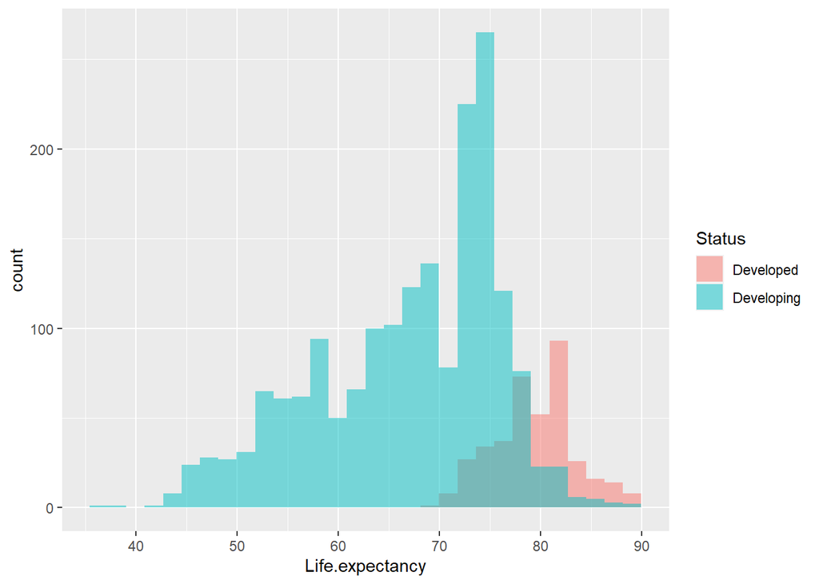

```r
ggplot(LifeExpData, aes(x=Life.expectancy, fill=Status)) +
  geom_histogram(alpha=0.5, position="identity")
```

Merge original dataset with country coordinates data. Then, convert coordinates to numeric. For latitude, make Southern values negative, and for longitude, make western values negative.

```r
Geo = read.csv(file = "Countries_Long_Lat.csv")
LifeExpData <- merge(x = LifeExpData, y = Geo, by = "Country")

LifeExpData$Latitude <- ifelse(str_detect(LifeExpData$Latitude, "S"), paste("-", LifeExpData$Latitude, sep=""), LifeExpData$Latitude)
LifeExpData$Latitude = substr(LifeExpData$Latitude,1,nchar(LifeExpData$Latitude)-1)
LifeExpData$Latitude <- as.numeric(LifeExpData$Latitude)

LifeExpData$Longitude <- ifelse(str_detect(LifeExpData$Longitude, "W"), paste("-", LifeExpData$Longitude, sep=""), LifeExpData$Longitude)
LifeExpData$Longitude = substr(LifeExpData$Longitude,1,nchar(LifeExpData$Longitude)-1)
LifeExpData$Longitude <- as.numeric(LifeExpData$Longitude)
```

Visualize lat and long against life expectancy

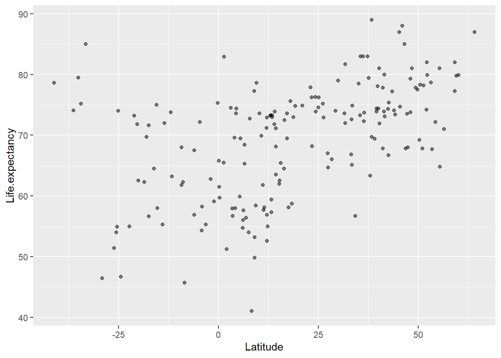

```r
ggplot(LifeExpData %>% distinct(Country, .keep_all = TRUE) , aes(y=Life.expectancy, x=Latitude)) + geom_point(alpha=0.5)
```

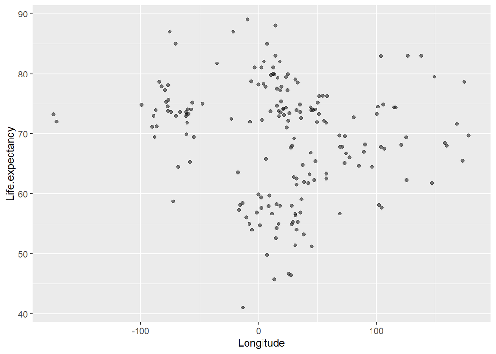

```r
ggplot(LifeExpData %>% distinct(Country, .keep_all = TRUE), aes(y=Life.expectancy, x=Longitude)) + geom_point(alpha=0.5)
```

```r
plot3d(
  z=LifeExpData$Life.expectancy, y=LifeExpData$Latitude, x=LifeExpData$Longitude,
  xlab="Longitude", ylab="Latitude", zlab="Life.expectancy")
```

View correlations between quantitative variables

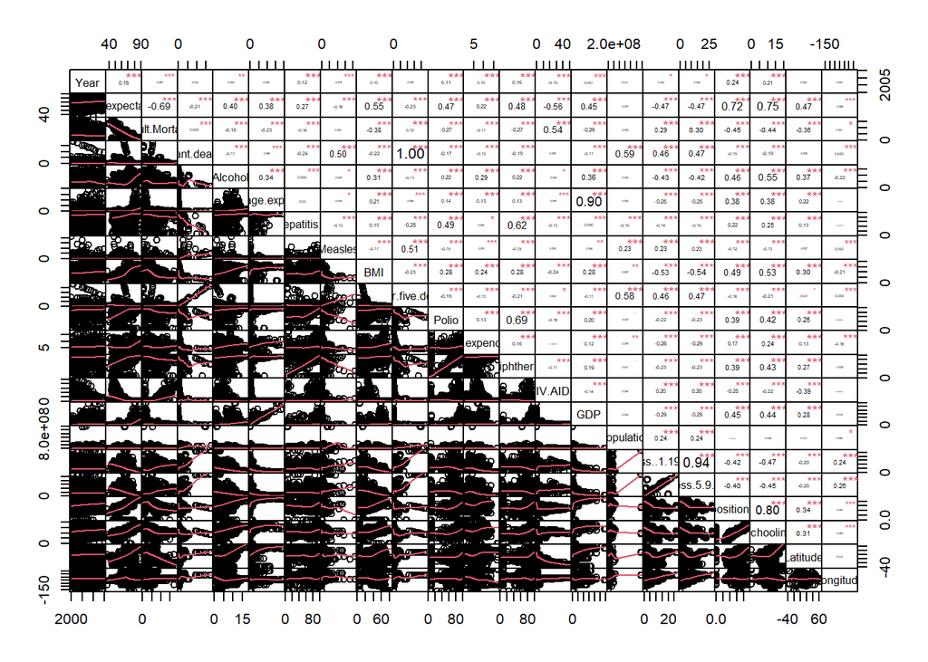

```r
quant <- subset(LifeExpData, select=-c(Country, Status))
chart.Correlation(quant, histogram=FALSE, pch=19)
```

We can see our response variable, LifeExpectancy, has correlations up to .75. Predictor variables have correlations up to 1 with one-another. Let’s view the scatterplots

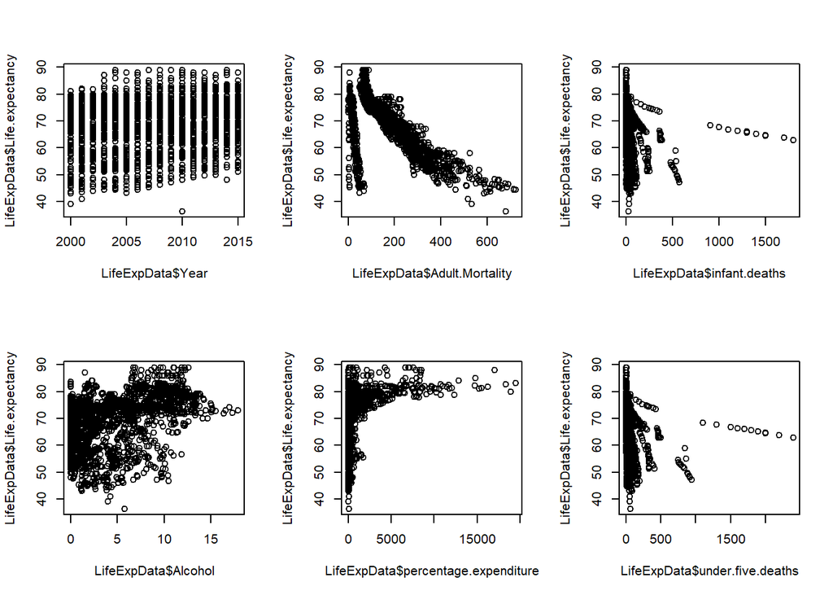

```r
par(mfrow=c(2,3))
plot(y = LifeExpData$Life.expectancy, x = LifeExpData$Year)
plot(y = LifeExpData$Life.expectancy, x = LifeExpData$Adult.Mortality)
plot(y = LifeExpData$Life.expectancy, x = LifeExpData$infant.deaths)
plot(y = LifeExpData$Life.expectancy, x = LifeExpData$Alcohol)
plot(y = LifeExpData$Life.expectancy, x = LifeExpData$percentage.expenditure)
plot(y = LifeExpData$Life.expectancy, x = LifeExpData$under.five.deaths)
```

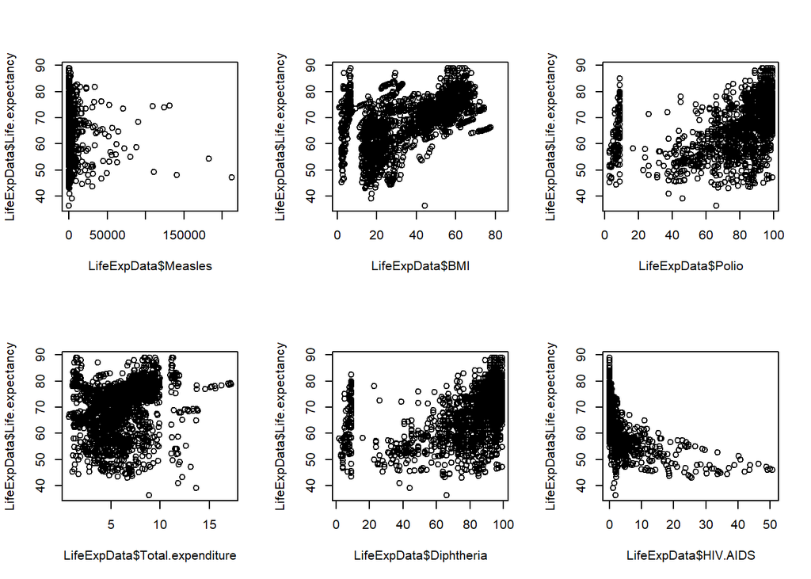

```r
plot(y = LifeExpData$Life.expectancy, x = LifeExpData$Measles)
plot(y = LifeExpData$Life.expectancy, x = LifeExpData$BMI)
plot(y = LifeExpData$Life.expectancy, x = LifeExpData$Polio)
plot(y = LifeExpData$Life.expectancy, x = LifeExpData$Total.expenditure)
plot(y = LifeExpData$Life.expectancy, x = LifeExpData$Diphtheria)
plot(y = LifeExpData$Life.expectancy, x = LifeExpData$HIV.AIDS)
```

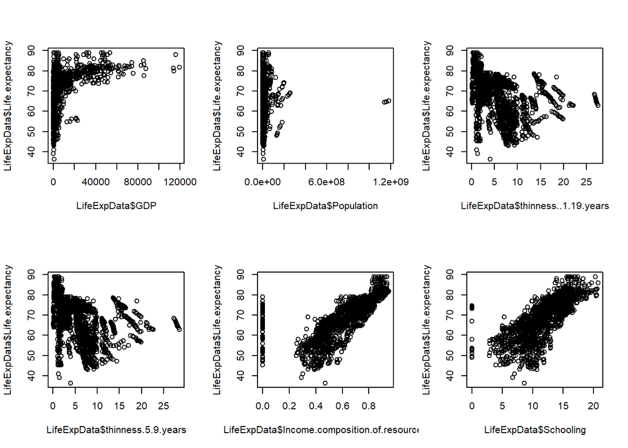

```r
plot(y = LifeExpData$Life.expectancy, x = LifeExpData$GDP)
plot(y = LifeExpData$Life.expectancy, x = LifeExpData$Population)
plot(y = LifeExpData$Life.expectancy, x = LifeExpData$thinness..1.19.years)
plot(y = LifeExpData$Life.expectancy, x = LifeExpData$thinness.5.9.years)
plot(y = LifeExpData$Life.expectancy, x = LifeExpData$Income.composition.of.resources)
plot(y = LifeExpData$Life.expectancy, x = LifeExpData$Schooling)
```

We can see a few points of concern, such as some strong outliers. Additionally, some variables have distinct branches, such as Adult.Mortality. Let’s explore these variables to see if we can determine the cause. First, we will color based off developed or undeveloped status.

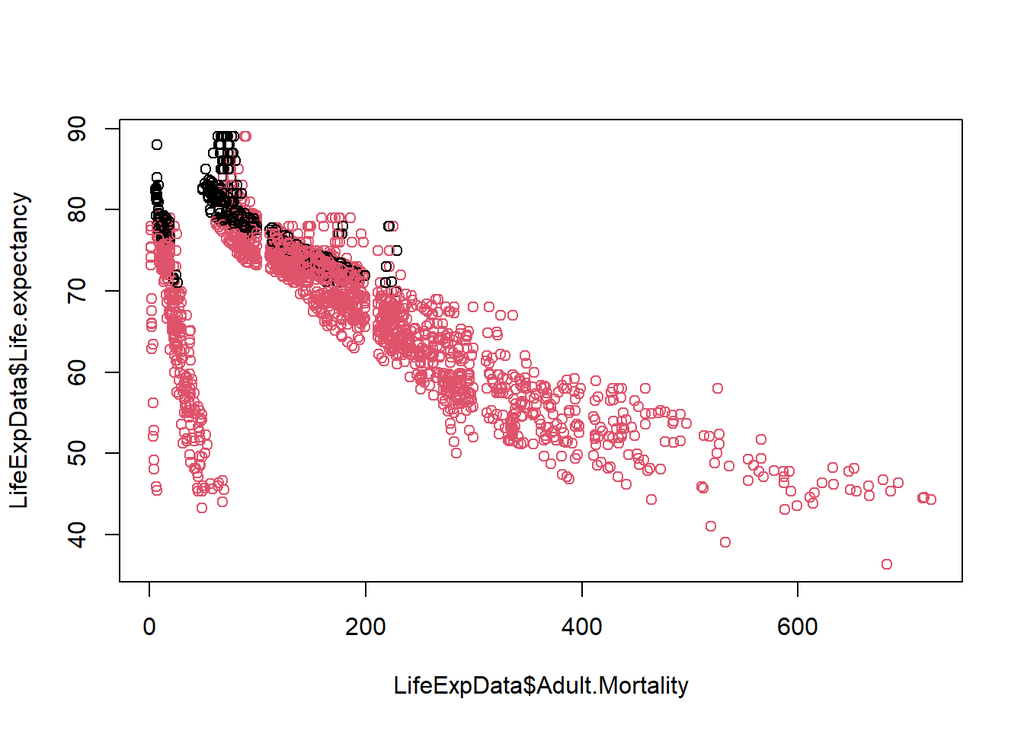

```r
plot(y = LifeExpData$Life.expectancy, x = LifeExpData$Adult.Mortality, col = LifeExpData$Status)
```

This does not solve the disparity, let’s see the individual data points between the two clusters

```r
LifeExpData %>% filter(Adult.Mortality < 40)
```

```
##                                                  Country Year     Status
## 1                                            Afghanistan 2002 Developing
## 2                                                Albania 2008 Developing
## 3                                                Albania 2001 Developing
## 4                                                Albania 2005 Developing
## 5                                                Albania 2003 Developing
## 6                                                Albania 2002 Developing
## 7                                                Albania 2000 Developing
## 8                                                Albania 2014 Developing
## 9                                                Albania 2007 Developing
## 10                                               Algeria 2004 Developing
## 11                                               Algeria 2014 Developing
## 12                                               Algeria 2015 Developing
## 13                                   Antigua and Barbuda 2015 Developing
## 14                                   Antigua and Barbuda 2009 Developing
```

[output cut: 2229 more lines]

```r
LifeExpData %>% filter(Adult.Mortality > 100)
```

```
##                                        Country Year     Status Life.expectancy
## 1                                  Afghanistan 2003 Developing            56.7
## 2                                  Afghanistan 2009 Developing            58.6
## 3                                  Afghanistan 2008 Developing            58.1
## 4                                  Afghanistan 2015 Developing            65.0
## 5                                  Afghanistan 2012 Developing            59.5
## 6                                  Afghanistan 2011 Developing            59.2
## 7                                  Afghanistan 2004 Developing            57.0
## 8                                  Afghanistan 2014 Developing            59.9
## 9                                  Afghanistan 2005 Developing            57.3
## 10                                 Afghanistan 2006 Developing            57.3
## 11                                 Afghanistan 2000 Developing            54.8
## 12                                 Afghanistan 2007 Developing            57.5
## 13                                     Algeria 2012 Developing            75.1
## 14                                     Algeria 2002 Developing            71.6
```

[output cut: 6895 more lines]

Counties frequently appear in both groups above. For example, Afghanistan has a 3 listed for Adult.Mortality in one year, and all the others years fall between 260 and 320. Similar situations occur with many other counties such as Armenia, South Sudan, and Spain. It seems clear the cause is a reporting error, in which countries incorrectly reported their statistic as per 100 population or per 10 population. It should be reported as per 1000 population.

Now, let’s examine similar situations from above. First, infant.deaths:

```r
LifeExpData %>% filter(infant.deaths < 500)
```

```
##                                                   Country Year     Status
## 1                                             Afghanistan 2003 Developing
## 2                                             Afghanistan 2009 Developing
## 3                                             Afghanistan 2008 Developing
## 4                                             Afghanistan 2015 Developing
## 5                                             Afghanistan 2012 Developing
## 6                                             Afghanistan 2011 Developing
## 7                                             Afghanistan 2004 Developing
## 8                                             Afghanistan 2014 Developing
## 9                                             Afghanistan 2005 Developing
## 10                                            Afghanistan 2002 Developing
## 11                                            Afghanistan 2006 Developing
## 12                                            Afghanistan 2000 Developing
## 13                                            Afghanistan 2007 Developing
## 14                                                Albania 2015 Developing
```

[output cut: 13083 more lines]

```r
LifeExpData %>% filter(infant.deaths > 750)
```

```
##    Country Year     Status Life.expectancy Adult.Mortality infant.deaths
## 1    India 2009 Developing            66.0               2          1300
## 2    India 2001 Developing            62.9             222          1800
## 3    India 2010 Developing            66.4             196          1200
## 4    India 2003 Developing            63.7             216          1700
## 5    India 2005 Developing            64.4             211          1500
## 6    India 2008 Developing            65.5              23          1300
## 7    India 2013 Developing            67.6             187          1000
## 8    India 2015 Developing            68.3             181           910
## 9    India 2011 Developing            66.8             193          1100
## 10   India 2007 Developing            65.2              26          1400
## 11   India 2006 Developing            64.8              28          1500
##    Alcohol percentage.expenditure Hepatitis.B Measles  BMI under.five.deaths
## 1     2.50              0.8441863          37   56188 15.4              1700
## 2     1.00             19.0034061          NA   51780 11.8              2400
```

[output cut: 45 more lines]

```r
LifeExpData %>% filter(Country == "India")
```

```
##    Country Year     Status Life.expectancy Adult.Mortality infant.deaths
## 1    India 2009 Developing            66.0               2          1300
## 2    India 2001 Developing            62.9             222          1800
## 3    India 2010 Developing            66.4             196          1200
## 4    India 2003 Developing            63.7             216          1700
## 5    India 2005 Developing            64.4             211          1500
## 6    India 2008 Developing            65.5              23          1300
## 7    India 2013 Developing            67.6             187          1000
## 8    India 2015 Developing            68.3             181           910
## 9    India 2011 Developing            66.8             193          1100
## 10   India 2007 Developing            65.2              26          1400
## 11   India 2006 Developing            64.8              28          1500
##    Alcohol percentage.expenditure Hepatitis.B Measles  BMI under.five.deaths
## 1     2.50              0.8441863          37   56188 15.4              1700
## 2     1.00             19.0034061          NA   51780 11.8              2400
```

[output cut: 45 more lines]

```r
LifeExpData %>% filter(infant.deaths > 480 & infant.deaths < 520)
```

```
##   Country Year     Status Life.expectancy Adult.Mortality infant.deaths Alcohol
## 1 Nigeria 2012 Developing            52.7             374           505    8.54
## 2 Nigeria 2015 Developing            54.5             344           483      NA
## 3 Nigeria 2013 Developing            53.2             367           498    8.30
## 4 Nigeria 2014 Developing            53.6             362           490    0.01
##   percentage.expenditure Hepatitis.B Measles  BMI under.five.deaths Polio
## 1               204.7186          42    6447 23.5               788    42
## 2                 0.0000          49   12423 25.4               747    49
## 3               194.2033          46   52852 24.1               773    46
## 4               263.2111          49    6855 24.7               759    49
##   Total.expenditure Diphtheria HIV.AIDS      GDP Population
## 1              3.30         42      4.4 2755.298  167297284
## 2                NA         49      3.7 2655.158  181181744
## 3              3.70         46      3.9 2996.964   17182933
## 4              3.67         49      3.9 3221.678    1764652
##   thinness..1.19.years thinness.5.9.years Income.composition.of.resources
## 1                  1.7                1.6                           0.507
## 2                  9.8                9.7                           0.525
## 3                  1.4                1.2                           0.514
## 4                  1.1                9.9                           0.521
##   Schooling Latitude Longitude
## 1       9.7     9.05      7.32
## 2      10.0     9.05      7.32
## 3       9.8     9.05      7.32
## 4      10.0     9.05      7.32
```

```r
LifeExpData %>% filter(Country == "Nigeria")
```

```
##    Country Year     Status Life.expectancy Adult.Mortality infant.deaths
## 1  Nigeria 2006 Developing            49.8             396           549
## 2  Nigeria 2012 Developing            52.7             374           505
## 3  Nigeria 2009 Developing            51.6             376           527
## 4  Nigeria 2015 Developing            54.5             344           483
## 5  Nigeria 2000 Developing            47.1              45           576
## 6  Nigeria 2008 Developing            59.0             386           536
## 7  Nigeria 2010 Developing            52.0             374           521
## 8  Nigeria 2013 Developing            53.2             367           498
## 9  Nigeria 2014 Developing            53.6             362           490
## 10 Nigeria 2004 Developing            48.5              47           563
## 11 Nigeria 2005 Developing            49.2               4           556
## 12 Nigeria 2007 Developing            55.0             388           542
## 13 Nigeria 2003 Developing            48.1              41           567
##    Alcohol percentage.expenditure Hepatitis.B Measles  BMI under.five.deaths
```

[output cut: 55 more lines]

infant.deaths do not seem to indicate any initial reporting errors. The differences seem to arise due to country.

Check out BMI:

```r
LifeExpData %>% filter(BMI < 8)
```

```
##                                                  Country Year     Status
## 1                                                Algeria 2007 Developing
## 2                                                 Angola 2010 Developing
## 3                                    Antigua and Barbuda 2004 Developing
## 4                                    Antigua and Barbuda 2003 Developing
## 5                                                Armenia 2009 Developing
## 6                                                Armenia 2008 Developing
## 7                                              Australia 2003  Developed
## 8                                              Australia 2004  Developed
## 9                                                Austria 2000  Developed
## 10                                               Austria 2001  Developed
## 11                                            Azerbaijan 2013 Developing
## 12                                               Bahamas 2009 Developing
## 13                                               Bahrain 2010 Developing
## 14                                               Bahrain 2011 Developing
```

[output cut: 1299 more lines]

```r
LifeExpData %>% filter(Country == "Antigua and Barbuda")
```

```
##                Country Year     Status Life.expectancy Adult.Mortality
## 1  Antigua and Barbuda 2000 Developing            73.6             156
## 2  Antigua and Barbuda 2015 Developing            76.4              13
## 3  Antigua and Barbuda 2011 Developing            75.7             136
## 4  Antigua and Barbuda 2010 Developing            75.6             138
## 5  Antigua and Barbuda 2004 Developing            74.4             149
## 6  Antigua and Barbuda 2001 Developing            73.8             154
## 7  Antigua and Barbuda 2007 Developing            75.0             144
## 8  Antigua and Barbuda 2006 Developing            74.8             145
## 9  Antigua and Barbuda 2009 Developing            75.4              14
## 10 Antigua and Barbuda 2008 Developing            75.2             142
## 11 Antigua and Barbuda 2003 Developing            74.2             151
## 12 Antigua and Barbuda 2012 Developing            75.9             134
## 13 Antigua and Barbuda 2005 Developing            74.6             147
## 14 Antigua and Barbuda 2013 Developing            76.1             133
```

[output cut: 60 more lines]

```r
LifeExpData %>% filter(Country == "Zimbabwe")
```

```
##     Country Year     Status Life.expectancy Adult.Mortality infant.deaths
## 1  Zimbabwe 2012 Developing            56.6             429            26
## 2  Zimbabwe 2003 Developing            44.5             715            26
## 3  Zimbabwe 2005 Developing            44.6             717            28
## 4  Zimbabwe 2015 Developing            67.0             336            22
## 5  Zimbabwe 2006 Developing            45.4               7            28
## 6  Zimbabwe 2004 Developing            44.3             723            27
## 7  Zimbabwe 2011 Developing            54.9             464            28
## 8  Zimbabwe 2008 Developing            48.2             632            30
## 9  Zimbabwe 2000 Developing            46.0             665            24
## 10 Zimbabwe 2013 Developing            58.0             399            25
## 11 Zimbabwe 2010 Developing            52.4             527            29
## 12 Zimbabwe 2001 Developing            45.3             686            25
## 13 Zimbabwe 2007 Developing            46.6              67            29
##    Alcohol percentage.expenditure Hepatitis.B Measles  BMI under.five.deaths
```

[output cut: 55 more lines]

```r
LifeExpData %>% filter(Country == "Portugal")
```

```
##     Country Year    Status Life.expectancy Adult.Mortality infant.deaths
## 1  Portugal 2014 Developed            89.0              78             0
## 2  Portugal 2000 Developed            76.6              11             1
## 3  Portugal 2005 Developed            77.7              11             0
## 4  Portugal 2013 Developed            86.0              79             0
## 5  Portugal 2012 Developed            83.0              81             0
## 6  Portugal 2010 Developed            79.6              88             0
## 7  Portugal 2011 Developed            82.0              85             0
## 8  Portugal 2008 Developed            79.0              92             0
## 9  Portugal 2006 Developed            78.5              96             0
## 10 Portugal 2015 Developed            81.1              76             0
## 11 Portugal 2007 Developed            78.7              94             0
## 12 Portugal 2001 Developed            76.9              11             1
## 13 Portugal 2004 Developed            78.0              99             0
## 14 Portugal 2003 Developed            77.3              15             0
```

[output cut: 60 more lines]

```r
LifeExpData %>% filter(Country == "Ireland")
```

```
##    Country Year    Status Life.expectancy Adult.Mortality infant.deaths Alcohol
## 1  Ireland 2005 Developed            78.7              78             0   13.31
## 2  Ireland 2004 Developed            78.3              82             0   13.32
## 3  Ireland 2015 Developed            81.4              64             0      NA
## 4  Ireland 2013 Developed            81.0              67             0   10.49
## 5  Ireland 2011 Developed            84.0               7             0   11.72
## 6  Ireland 2009 Developed            79.7              77             0   11.41
## 7  Ireland 2014 Developed            81.2              66             0   10.75
## 8  Ireland 2001 Developed            77.0              89             0   14.27
## 9  Ireland 2006 Developed            79.0              78             0   13.44
## 10 Ireland 2002 Developed            77.4              88             0   14.17
## 11 Ireland 2008 Developed            79.8              75             0   12.66
## 12 Ireland 2010 Developed            86.0              68             0   11.88
## 13 Ireland 2003 Developed            78.0              82             0   13.24
## 14 Ireland 2012 Developed            85.0              69             0   11.49
```

[output cut: 60 more lines]

```r
LifeExpData %>% filter(Country == "Equatorial Guinea")
```

```
##              Country Year     Status Life.expectancy Adult.Mortality
## 1  Equatorial Guinea 2014 Developing            57.9              32
## 2  Equatorial Guinea 2012 Developing            56.7             337
## 3  Equatorial Guinea 2004 Developing            54.1             336
## 4  Equatorial Guinea 2003 Developing            53.8             334
## 5  Equatorial Guinea 2015 Developing            58.2              32
## 6  Equatorial Guinea 2002 Developing            53.5             334
## 7  Equatorial Guinea 2013 Developing            57.4             327
## 8  Equatorial Guinea 2009 Developing            55.7              34
## 9  Equatorial Guinea 2008 Developing            55.4             338
## 10 Equatorial Guinea 2011 Developing            56.2             344
## 11 Equatorial Guinea 2005 Developing            54.4             337
## 12 Equatorial Guinea 2010 Developing            56.1             339
## 13 Equatorial Guinea 2000 Developing            52.7             336
## 14 Equatorial Guinea 2007 Developing            55.0             339
```

[output cut: 70 more lines]

Similar to the Adult.Mortality, there appears to be a reporting error. For example, Equatorial Guinea lists BMI around 19-23, and then has a couple 2.9 and 2.5. If you multiple the abnormally low numbers time 10, however, the adjusted numbers would be higher than all the rest. This holds true for the other four countries tested as well.

Next, let’s examine Polio for errors:

```r
LifeExpData %>% filter(Polio < 18)
```

```
##                                Country Year     Status Life.expectancy
## 1                          Afghanistan 2015 Developing            65.0
## 2                          Afghanistan 2004 Developing            57.0
## 3                               Angola 2000 Developing            45.3
## 4                               Angola 2004 Developing            47.1
## 5                               Angola 2015 Developing            52.4
## 6                               Angola 2003 Developing            46.8
## 7                            Australia 2000  Developed            79.5
## 8                           Azerbaijan 2006 Developing            69.2
## 9                             Barbados 2010 Developing            74.7
## 10                            Barbados 2003 Developing            73.7
## 11                               Benin 2012 Developing            59.3
## 12                               Benin 2009 Developing            58.4
## 13                              Bhutan 2004 Developing            64.2
## 14              Bosnia and Herzegovina 2010 Developing            76.4
```

[output cut: 640 more lines]

```r
LifeExpData %>% filter(Country == "Afghanistan")
```

```
##        Country Year     Status Life.expectancy Adult.Mortality infant.deaths
## 1  Afghanistan 2003 Developing            56.7             295            87
## 2  Afghanistan 2009 Developing            58.6             281            77
## 3  Afghanistan 2008 Developing            58.1             287            80
## 4  Afghanistan 2015 Developing            65.0             263            62
## 5  Afghanistan 2012 Developing            59.5             272            69
## 6  Afghanistan 2011 Developing            59.2             275            71
## 7  Afghanistan 2004 Developing            57.0             293            87
## 8  Afghanistan 2014 Developing            59.9             271            64
## 9  Afghanistan 2005 Developing            57.3             291            85
## 10 Afghanistan 2002 Developing            56.2               3            88
## 11 Afghanistan 2006 Developing            57.3             295            84
## 12 Afghanistan 2000 Developing            54.8             321            88
## 13 Afghanistan 2007 Developing            57.5             295            82
##    Alcohol percentage.expenditure Hepatitis.B Measles  BMI under.five.deaths
```

[output cut: 55 more lines]

```r
LifeExpData %>% filter(Country == "Guatemala")
```

```
##      Country Year     Status Life.expectancy Adult.Mortality infant.deaths
## 1  Guatemala 2011 Developing            71.1             193            11
## 2  Guatemala 2010 Developing            77.0             196            12
## 3  Guatemala 2013 Developing            71.4             189            11
## 4  Guatemala 2005 Developing            69.2              28            14
## 5  Guatemala 2003 Developing            69.4              24            15
## 6  Guatemala 2009 Developing            76.0             198            12
## 7  Guatemala 2006 Developing            69.7              24            14
## 8  Guatemala 2004 Developing            69.6              21            15
## 9  Guatemala 2002 Developing            69.3              21            16
## 10 Guatemala 2014 Developing            71.7             187            10
## 11 Guatemala 2008 Developing            79.0              19            13
## 12 Guatemala 2012 Developing            71.3             189            11
## 13 Guatemala 2001 Developing            68.4             211            16
##    Alcohol percentage.expenditure Hepatitis.B Measles  BMI under.five.deaths
```

[output cut: 55 more lines]

```r
LifeExpData %>% filter(Country == "Madagascar")
```

```
##       Country Year     Status Life.expectancy Adult.Mortality infant.deaths
## 1  Madagascar 2008 Developing            62.3             259            34
## 2  Madagascar 2005 Developing            69.0             265            37
## 3  Madagascar 2012 Developing            64.3             235            30
## 4  Madagascar 2001 Developing            58.7             276            42
## 5  Madagascar 2010 Developing            63.3             248            32
## 6  Madagascar 2004 Developing            64.0             267            38
## 7  Madagascar 2011 Developing            63.8             241            31
## 8  Madagascar 2015 Developing            65.5              22            28
## 9  Madagascar 2013 Developing            64.7              23            29
## 10 Madagascar 2009 Developing            62.8             254            33
## 11 Madagascar 2003 Developing            59.9             268            40
##    Alcohol percentage.expenditure Hepatitis.B Measles  BMI under.five.deaths
## 1     0.68               6.448763          77       3 17.1                49
## 2     0.72              33.747862          81       0 15.8                56
```

[output cut: 45 more lines]

```r
LifeExpData %>% filter(Country == "Saint Lucia")
```

```
##        Country Year     Status Life.expectancy Adult.Mortality infant.deaths
## 1  Saint Lucia 2001 Developing            71.8             178             0
## 2  Saint Lucia 2011 Developing            74.6             143             0
## 3  Saint Lucia 2003 Developing            72.2             171             0
## 4  Saint Lucia 2004 Developing            72.6             166             0
## 5  Saint Lucia 2012 Developing            74.7             142             0
## 6  Saint Lucia 2008 Developing            74.1             149             0
## 7  Saint Lucia 2002 Developing            72.0             174             0
## 8  Saint Lucia 2009 Developing            74.3             147             0
## 9  Saint Lucia 2015 Developing            75.2             138             0
## 10 Saint Lucia 2010 Developing            74.2             147             0
##    Alcohol percentage.expenditure Hepatitis.B Measles  BMI under.five.deaths
## 1    12.03                      0          NA       0 37.3                 0
## 2    10.43                      0          99       0 44.5                 0
## 3    12.55                      0          84       0 38.4                 0
```

[output cut: 40 more lines]

```r
LifeExpData %>% filter(Country == "United States of America")
```

```
##                     Country Year    Status Life.expectancy Adult.Mortality
## 1  United States of America 2007 Developed            78.1              11
## 2  United States of America 2014 Developed            79.1              14
## 3  United States of America 2001 Developed            76.9             115
## 4  United States of America 2013 Developed            78.9              16
## 5  United States of America 2004 Developed            77.5             111
## 6  United States of America 2009 Developed            78.5              18
## 7  United States of America 2008 Developed            78.2              18
## 8  United States of America 2006 Developed            77.8             113
## 9  United States of America 2012 Developed            78.8              16
## 10 United States of America 2000 Developed            76.8             114
## 11 United States of America 2002 Developed            77.0             115
## 12 United States of America 2003 Developed            77.2             114
## 13 United States of America 2010 Developed            78.7              15
## 14 United States of America 2015 Developed            79.3              13
```

[output cut: 60 more lines]

Polio appears to have the same reporting errors.

Check now for Diphtheria:

```r
LifeExpData %>% filter(Diphtheria < 20)
```

```
##                                Country Year     Status Life.expectancy
## 1                          Afghanistan 2004 Developing            57.0
## 2                               Angola 2004 Developing            47.1
## 3                               Angola 2003 Developing            46.8
## 4                            Australia 2000  Developed            79.5
## 5                                Benin 2012 Developing            59.3
## 6                                Benin 2005 Developing            56.5
## 7               Bosnia and Herzegovina 2009 Developing            76.1
## 8                              Burundi 2000 Developing            58.0
## 9                       CÃ´te d'Ivoire 2013 Developing            52.3
## 10                          Cabo Verde 2000 Developing            69.9
## 11                          Cabo Verde 2001 Developing            73.0
## 12                            Cambodia 2006 Developing            64.1
## 13                            Cambodia 2001 Developing            58.5
## 14                            Cameroon 2005 Developing            52.8
```

[output cut: 635 more lines]

```r
LifeExpData %>% filter(Country == "Burundi")
```

```
##    Country Year     Status Life.expectancy Adult.Mortality infant.deaths
## 1  Burundi 2008 Developing            55.3              35            23
## 2  Burundi 2011 Developing            57.4             321            22
## 3  Burundi 2010 Developing            56.8              33            23
## 4  Burundi 2001 Developing            51.3             385            25
## 5  Burundi 2007 Developing            54.8             355            24
## 6  Burundi 2015 Developing            59.6             288            21
## 7  Burundi 2000 Developing            58.0             386            25
## 8  Burundi 2002 Developing            51.5             387            24
## 9  Burundi 2012 Developing            58.0             312            22
## 10 Burundi 2006 Developing            54.1             361            24
## 11 Burundi 2013 Developing            58.6              33            22
##    Alcohol percentage.expenditure Hepatitis.B Measles  BMI under.five.deaths
## 1     4.33              15.994152          92     173 15.2                35
## 2     4.16               3.595980          96     129 16.6                33
```

[output cut: 45 more lines]

```r
LifeExpData %>% filter(Country == "Democratic Republic of the Congo")
```

```
##                             Country Year     Status Life.expectancy
## 1  Democratic Republic of the Congo 2005 Developing            54.3
## 2  Democratic Republic of the Congo 2009 Developing            56.7
## 3  Democratic Republic of the Congo 2002 Developing            52.1
## 4  Democratic Republic of the Congo 2015 Developing            59.8
## 5  Democratic Republic of the Congo 2012 Developing            58.3
## 6  Democratic Republic of the Congo 2000 Developing            51.3
## 7  Democratic Republic of the Congo 2001 Developing            51.8
## 8  Democratic Republic of the Congo 2004 Developing            53.5
## 9  Democratic Republic of the Congo 2007 Developing            55.7
## 10 Democratic Republic of the Congo 2013 Developing            58.8
## 11 Democratic Republic of the Congo 2006 Developing            55.0
## 12 Democratic Republic of the Congo 2008 Developing            56.3
## 13 Democratic Republic of the Congo 2014 Developing            59.3
##    Adult.Mortality infant.deaths Alcohol percentage.expenditure Hepatitis.B
```

[output cut: 55 more lines]

```r
LifeExpData %>% filter(Country == "Liberia")
```

```
##    Country Year     Status Life.expectancy Adult.Mortality infant.deaths
## 1  Liberia 2002 Developing            56.0             371            13
## 2  Liberia 2008 Developing            58.6             281            10
## 3  Liberia 2006 Developing            56.7              32            11
## 4  Liberia 2014 Developing            58.1             329             8
## 5  Liberia 2001 Developing            51.5             333            14
## 6  Liberia 2000 Developing            51.9              39            14
## 7  Liberia 2007 Developing            57.9             286            10
## 8  Liberia 2005 Developing            55.3             316            12
## 9  Liberia 2012 Developing            67.0             261             9
## 10 Liberia 2013 Developing            61.1             258             9
##    Alcohol percentage.expenditure Hepatitis.B Measles  BMI under.five.deaths
## 1     4.27              10.424369          NA     131  2.7                19
## 2     3.88              40.033441          64       1 23.4                14
## 3     4.05              15.799342          NA      20 22.4                15
```

[output cut: 40 more lines]

```r
LifeExpData %>% filter(Country == "Somalia")
```

```
##    Country Year     Status Life.expectancy Adult.Mortality infant.deaths
## 1  Somalia 2004 Developing            51.2             341            49
## 2  Somalia 2011 Developing            53.1             329            51
## 3  Somalia 2006 Developing            51.5             337            51
## 4  Somalia 2003 Developing            51.1             344            48
## 5  Somalia 2009 Developing            52.2             335            52
## 6  Somalia 2005 Developing            51.6             334            50
## 7  Somalia 2007 Developing            51.5              34            52
## 8  Somalia 2015 Developing            55.0             312            50
## 9  Somalia 2012 Developing            53.1             336            51
## 10 Somalia 2010 Developing            52.4             336            52
## 11 Somalia 2001 Developing            57.0             352            46
## 12 Somalia 2002 Developing            58.0             348            47
## 13 Somalia 2013 Developing            54.2             318            51
## 14 Somalia 2000 Developing            55.0             355            45
```

[output cut: 60 more lines]

```r
LifeExpData %>% filter(Country == "Uruguay")
```

```
##    Country Year     Status Life.expectancy Adult.Mortality infant.deaths
## 1  Uruguay 2001 Developing            75.2             123             1
## 2  Uruguay 2012 Developing            76.5             118             0
## 3  Uruguay 2005 Developing            75.7             123             1
## 4  Uruguay 2010 Developing            76.3             118             0
## 5  Uruguay 2015 Developing            77.0             116             0
## 6  Uruguay 2004 Developing            75.4             122             1
## 7  Uruguay 2003 Developing            75.4             121             1
## 8  Uruguay 2000 Developing            75.1             131             1
## 9  Uruguay 2009 Developing            76.6             118             0
## 10 Uruguay 2007 Developing            75.4             124             1
## 11 Uruguay 2002 Developing            75.4             124             1
## 12 Uruguay 2013 Developing            76.8             117             0
## 13 Uruguay 2011 Developing            77.0             111             0
## 14 Uruguay 2008 Developing            76.4             119             1
```

[output cut: 60 more lines]

Again, Diphtheria appears to have the same reporting errors.

Now, check for Income.composition.of.resources errors:

```r
LifeExpData %>% filter(Income.composition.of.resources < .1)
```

```
##                                      Country Year     Status Life.expectancy
## 1                        Antigua and Barbuda 2000 Developing            73.6
## 2                        Antigua and Barbuda 2004 Developing            74.4
## 3                        Antigua and Barbuda 2001 Developing            73.8
## 4                        Antigua and Barbuda 2003 Developing            74.2
## 5                        Antigua and Barbuda 2005 Developing            74.6
## 6                                    Bahamas 2000 Developing            72.6
## 7                                     Bhutan 2008 Developing            67.0
## 8                                     Bhutan 2004 Developing            64.2
## 9                                     Bhutan 2001 Developing            61.7
## 10                                    Bhutan 2007 Developing            66.5
## 11                                    Bhutan 2010 Developing            67.9
## 12                                    Bhutan 2005 Developing            65.0
## 13                                    Bhutan 2009 Developing            67.4
## 14                                    Bhutan 2000 Developing            62.0
```

[output cut: 455 more lines]

```r
LifeExpData %>% filter(Country == "Bahamas")
```

```
##    Country Year     Status Life.expectancy Adult.Mortality infant.deaths
## 1  Bahamas 2009 Developing            74.6             168             0
## 2  Bahamas 2012 Developing            74.9             167             0
## 3  Bahamas 2011 Developing            75.0             162             0
## 4  Bahamas 2007 Developing            74.4             167             0
## 5  Bahamas 2001 Developing            72.9             189             0
## 6  Bahamas 2000 Developing            72.6             192             0
## 7  Bahamas 2010 Developing            75.0             161             0
## 8  Bahamas 2015 Developing            76.1             147             0
## 9  Bahamas 2013 Developing            74.8             172             0
## 10 Bahamas 2006 Developing            74.2             171             0
##    Alcohol percentage.expenditure Hepatitis.B Measles  BMI under.five.deaths
## 1     9.29                      0          95       0  6.7                 0
## 2     9.50                      0          96       0 62.6                 0
## 3     9.34                      0          95       0 62.0                 0
```

[output cut: 40 more lines]

```r
LifeExpData %>% filter(Country == "Comoros")
```

```
##    Country Year     Status Life.expectancy Adult.Mortality infant.deaths
## 1  Comoros 2014 Developing            63.2              23             1
## 2  Comoros 2003 Developing            59.6             271             2
## 3  Comoros 2002 Developing            59.5             271             2
## 4  Comoros 2001 Developing            59.5             272             1
## 5  Comoros 2009 Developing            61.3             251             2
## 6  Comoros 2006 Developing            63.0             262             2
## 7  Comoros 2010 Developing            61.8             246             2
## 8  Comoros 2007 Developing            66.0             259             2
## 9  Comoros 2000 Developing            59.5             272             1
## 10 Comoros 2011 Developing            62.2             241             2
## 11 Comoros 2015 Developing            63.5             227             1
## 12 Comoros 2005 Developing            60.0             266             2
## 13 Comoros 2012 Developing            62.5             237             2
##    Alcohol percentage.expenditure Hepatitis.B Measles  BMI under.five.deaths
```

[output cut: 55 more lines]

```r
LifeExpData %>% filter(Country == "Kiribati")
```

```
##     Country Year     Status Life.expectancy Adult.Mortality infant.deaths
## 1  Kiribati 2011 Developing            65.5              26             0
## 2  Kiribati 2004 Developing            64.8             214             0
## 3  Kiribati 2013 Developing            65.8              22             0
## 4  Kiribati 2000 Developing            64.1             222             0
## 5  Kiribati 2001 Developing            64.3             219             0
## 6  Kiribati 2015 Developing            66.3             198             0
## 7  Kiribati 2014 Developing            66.1               2             0
## 8  Kiribati 2005 Developing            64.9             213             0
## 9  Kiribati 2007 Developing            65.0             211             0
## 10 Kiribati 2008 Developing            65.1              21             0
## 11 Kiribati 2010 Developing            65.3              27             0
## 12 Kiribati 2012 Developing            65.7              24             0
## 13 Kiribati 2006 Developing            65.0             212             0
##    Alcohol percentage.expenditure Hepatitis.B Measles  BMI under.five.deaths
```

[output cut: 55 more lines]

```r
LifeExpData %>% filter(Country == "South Sudan")
```

```
##        Country Year     Status Life.expectancy Adult.Mortality infant.deaths
## 1  South Sudan 2013 Developing            56.4             345            26
## 2  South Sudan 2012 Developing            56.0             347            26
## 3  South Sudan 2006 Developing            52.5             383            28
## 4  South Sudan 2000 Developing            48.9              38            31
## 5  South Sudan 2004 Developing            51.4             383            29
## 6  South Sudan 2015 Developing            57.3             332            26
## 7  South Sudan 2007 Developing            53.1             381            27
## 8  South Sudan 2008 Developing            53.6             377            27
## 9  South Sudan 2001 Developing            49.6             381            30
## 10 South Sudan 2003 Developing            58.0             383            29
##    Alcohol percentage.expenditure Hepatitis.B Measles BMI under.five.deaths
## 1       NA               47.44453          NA     525  NA                40
## 2       NA               38.33823          NA    1952  NA                40
## 3       NA                0.00000          NA       0  NA                43
```

[output cut: 40 more lines]

```r
LifeExpData %>% filter(Country == "Vanuatu")
```

```
##    Country Year     Status Life.expectancy Adult.Mortality infant.deaths
## 1  Vanuatu 2013 Developing            71.6             135             0
## 2  Vanuatu 2008 Developing            75.0             153             0
## 3  Vanuatu 2003 Developing            69.4             173             0
## 4  Vanuatu 2004 Developing            69.6             169             0
## 5  Vanuatu 2012 Developing            71.4             138             0
## 6  Vanuatu 2002 Developing            69.3             176             0
## 7  Vanuatu 2007 Developing            73.0             157             0
## 8  Vanuatu 2010 Developing            71.0             145             0
## 9  Vanuatu 2000 Developing            69.0              18             0
## 10 Vanuatu 2014 Developing            71.7             134             0
## 11 Vanuatu 2009 Developing            78.0             149             0
## 12 Vanuatu 2005 Developing            69.9             165             0
##    Alcohol percentage.expenditure Hepatitis.B Measles  BMI under.five.deaths
## 1     0.01              447.54564          64       0 51.7                 0
```

[output cut: 50 more lines]

The errors in these entries occur due to 0 values. They were likely supposed to be null, but were submitted as 0.00 instead. These will need to be corrected.

Under the Population variable, there appears to be some major outliers. Let’s investigate further.

```r
LifeExpData %>% filter(Population > 500000000)
```

```
##   Country Year     Status Life.expectancy Adult.Mortality infant.deaths Alcohol
## 1   India 2005 Developing            64.4             211          1500    1.27
## 2   India 2007 Developing            65.2              26          1400    1.59
## 3   India 2006 Developing            64.8              28          1500    1.37
##   percentage.expenditure Hepatitis.B Measles  BMI under.five.deaths Polio
## 1               3.509637           8   36711 13.5              2000    65
## 2               5.234770           6   41144 14.4              1900    67
## 3              34.859427           6   64185 13.9              2000    66
##   Total.expenditure Diphtheria HIV.AIDS      GDP Population
## 1              4.28         65      0.3  77.8190 1144118674
## 2              4.23         64      0.3 118.1664 1179681239
## 3              4.25         65      0.3 792.2597 1161977719
##   thinness..1.19.years thinness.5.9.years Income.composition.of.resources
## 1                 27.2               28.1                           0.526
## 2                 27.1               28.0                           0.546
## 3                 27.1               28.0                           0.536
##   Schooling Latitude Longitude
## 1       9.4    28.37     77.13
## 2       9.9    28.37     77.13
## 3       9.7    28.37     77.13
```

```r
LifeExpData %>% filter(Country == "India")
```

```
##    Country Year     Status Life.expectancy Adult.Mortality infant.deaths
## 1    India 2009 Developing            66.0               2          1300
## 2    India 2001 Developing            62.9             222          1800
## 3    India 2010 Developing            66.4             196          1200
## 4    India 2003 Developing            63.7             216          1700
## 5    India 2005 Developing            64.4             211          1500
## 6    India 2008 Developing            65.5              23          1300
## 7    India 2013 Developing            67.6             187          1000
## 8    India 2015 Developing            68.3             181           910
## 9    India 2011 Developing            66.8             193          1100
## 10   India 2007 Developing            65.2              26          1400
## 11   India 2006 Developing            64.8              28          1500
##    Alcohol percentage.expenditure Hepatitis.B Measles  BMI under.five.deaths
## 1     2.50              0.8441863          37   56188 15.4              1700
## 2     1.00             19.0034061          NA   51780 11.8              2400
```

[output cut: 45 more lines]

India should have a population above 1 billion each year, but is often in the tens/hundreds of millions in the dataset. China should have very large populations as well, but they range from 13,000 to 1.4 million. These should be about 1.4 billion. In addition, some major countries like the U.S. are missing all of its population data.

Let’s investigate the outlines for GDP

```r
LifeExpData %>% filter(GDP > 100000)
```

```
##      Country Year    Status Life.expectancy Adult.Mortality infant.deaths
## 1 Luxembourg 2013 Developed            81.4              68             0
## 2 Luxembourg 2014 Developed            81.7              65             0
## 3 Luxembourg 2011 Developed            88.0              72             0
## 4 Luxembourg 2008 Developed            80.0               8             0
##   Alcohol percentage.expenditure Hepatitis.B Measles  BMI under.five.deaths
## 1   11.02               15515.75          94       0  6.5                 0
## 2   11.12               16255.16          94       0  6.9                 0
## 3   11.50               17028.53          95       6 59.6                 0
## 4   11.53               18961.35          94       1 58.4                 0
##   Polio Total.expenditure Diphtheria HIV.AIDS      GDP Population
## 1    99              7.10         99      0.1 113751.9      54336
## 2    99              6.94         99      0.1 119172.7     556319
## 3    96              7.34         99      0.1 115761.6     518347
## 4    96              7.34         99      0.1 114293.8      48865
##   thinness..1.19.years thinness.5.9.years Income.composition.of.resources
## 1                  0.9                0.9                           0.892
## 2                  1.0                0.9                           0.892
## 3                  0.9                0.9                           0.894
## 4                  0.9                0.9                           0.887
##   Schooling Latitude Longitude
## 1      13.9    49.37      6.09
## 2      13.9    49.37      6.09
## 3      13.9    49.37      6.09
## 4      13.5    49.37      6.09
```

```r
LifeExpData %>% filter(Country == "Luxembourg")
```

```
##       Country Year    Status Life.expectancy Adult.Mortality infant.deaths
## 1  Luxembourg 2000 Developed            77.8              98             0
## 2  Luxembourg 2007 Developed            79.7              82             0
## 3  Luxembourg 2001 Developed            78.0              96             0
## 4  Luxembourg 2005 Developed            78.8               9             0
## 5  Luxembourg 2013 Developed            81.4              68             0
## 6  Luxembourg 2012 Developed            81.1               7             0
## 7  Luxembourg 2002 Developed            78.3              95             0
## 8  Luxembourg 2010 Developed            86.0              73             0
## 9  Luxembourg 2014 Developed            81.7              65             0
## 10 Luxembourg 2011 Developed            88.0              72             0
## 11 Luxembourg 2009 Developed            83.0              76             0
## 12 Luxembourg 2008 Developed            80.0               8             0
## 13 Luxembourg 2004 Developed            78.7              92             0
##    Alcohol percentage.expenditure Hepatitis.B Measles  BMI under.five.deaths
```

[output cut: 55 more lines]

The Luxembourg GDP variable (which is GDP per capita) fluctuates from 1.6k to 120k. There is a reporting error here. There may be some other inconsistent GDPs for other countries that were not investigated.